# Project Week 6

Ananda Putra Wijaya/G1401221111

2024-09-29

# Library

```r
library(ggplot2)
library(tsibble)
library(tseries)
library(MASS)
library(forecast)
library(TSA)
library(TTR)
library(aTSA)
library(graphics)
library(readxl)
library(tseries)
```

# Inisiasi Data

```r
data=read.csv("C:/Tugas/Semester 5/Metode Peramalan Deret Waktu/Minggu 6/Data Project Week 6.csv")
dts=ts(data$Jumlah)
dts
```

```
## Time Series:
## Start = 1
## End = 100
## Frequency = 1
##   [1] 26143 23206 22881 25195 32969 43737 26978 26481 23576 21380 24178 24707
##  [13] 24342 27480 16959 17602 22629 23796 23278 26563 29581 30305 25772 25006
##  [25] 26430 27759 29510 43121 63483 37762 21135 27153 31129 31386  4867 40311
##  [37] 33329 30072 31216  4558 34288 38859 43320 36202 32508 27965 21681 34025
##  [49] 38681  5900 33262 29314 29518 29897  5755 33585 35318 26535 24708  3529
##  [61] 27050 26904 30677 29970  3279 22947 23842 24667 25955 28964 30509 21687
##  [73] 23289 23558 24060 25704 28110 15982 23174 20570 23389 25781 25265 28964
##  [85] 10770 23207 23411 21038 20990 13298 30842 24253 21532 11211 18064 11208
##  [97] 25709 29339 26043 23868
```

## Eksplorasi Data penuh

### Plot Penuh

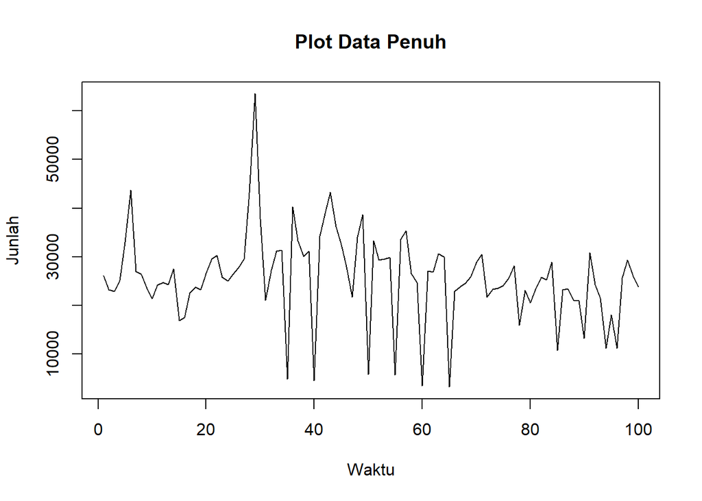

```r
plot.ts(dts, lty=1, xlab="Waktu", ylab="Junlah", main="Plot Data Penuh")
```

Berdasarkan plot deret waktu di atas, terlihat bahwa data cenderung memiliki pola musiman yang tidak stasioner dalam rataan. Selanjutnya akan dilakukan pembagian data latih dan data uji ditetapkan dengan proporsi 66%:34%.

### Plot Latih

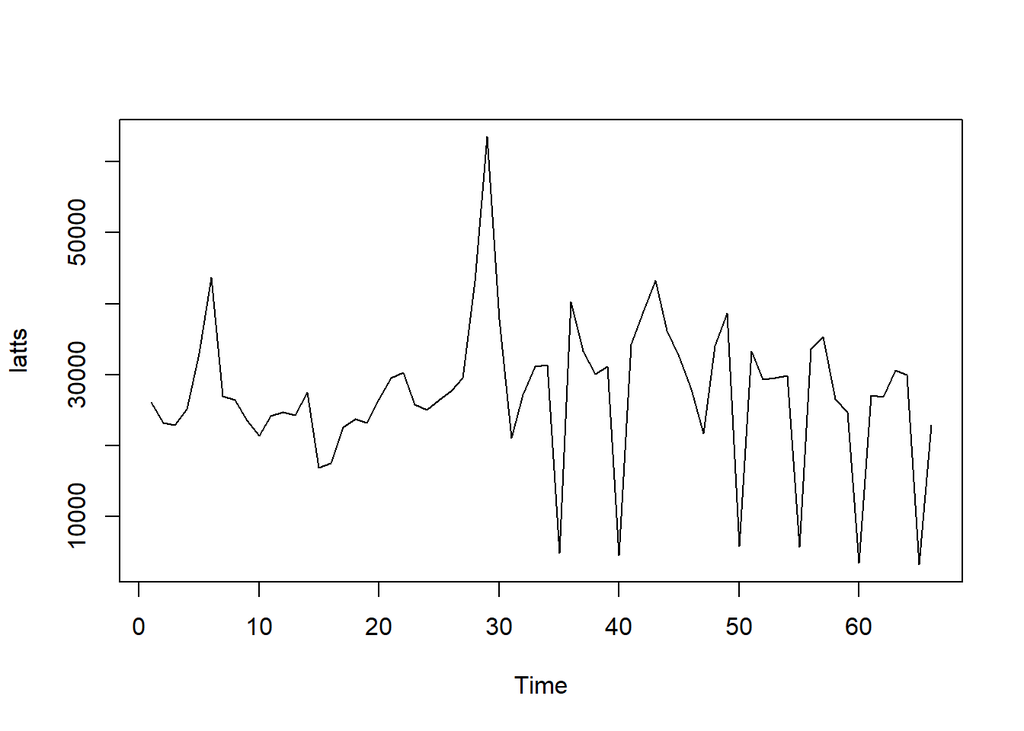

```r
latts=dts[1:66]
plot.ts(latts)
```

Data latih terlihat memiliki kecenderungan stasioner dalam ragam namun tidak stasioner dalam rataan.

### Plot Uji

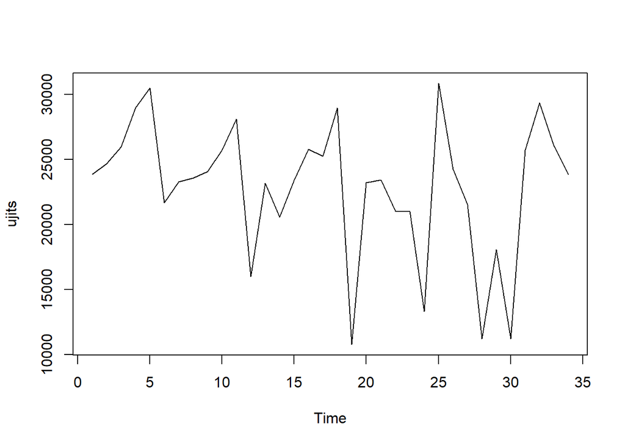

```r
ujits=dts[67:100]
plot.ts(ujits)
```

Data uji menunjukkan kecenderungan stasioner dalam rataan namun tidak stasioner dalam ragam.

# Uji Kestasioneran data

## Plot ACF

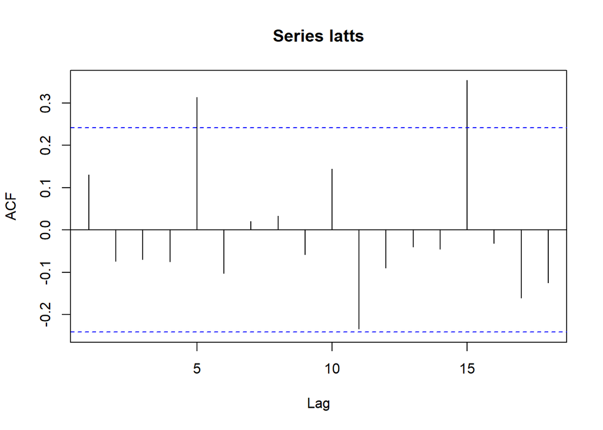

```r
acf(latts)
```

Plot ACF di atas menunjukkan bahwa data latih tidak *tails of slowly*.

## Uji ADF

```r
tseries::adf.test(latts)
```

```
##
##  Augmented Dickey-Fuller Test
##
## data:  latts
## Dickey-Fuller = -2.413, Lag order = 4, p-value = 0.4075
## alternative hypothesis: stationary
```

$H_0$ : Data tidak stasioner dalam rataan

$H_1$ : Data stasioner dalam rataan

Nilai p yang didapat adalah 0.4, yang mana lebih dari 0.05, artinya tak tolak H0. Maka data latih tidak stasioner dalam rataan. Hal ini sesuai dengan eksplorasi plot deret waktu dan plot ACF.

## Plot Box-Cox

```r
index <- seq(1:66)
bc = boxcox(latts~index, lambda = seq(0,3,by=1))
```

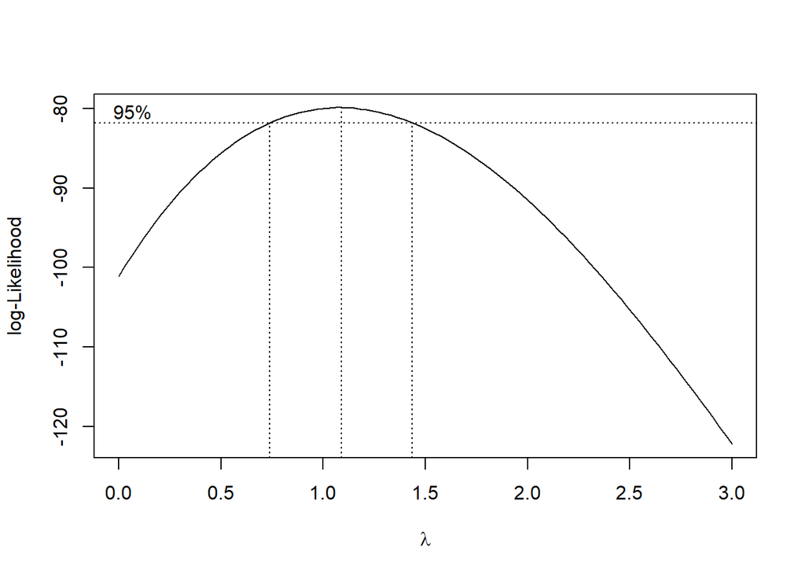

```r
#Nilai Rounded Lambda
lambda <- bc$x[which.max(bc$y)]
lambda
```

```
## [1] 1.090909
```

```r
#SK
bc$x[bc$y > max(bc$y) - 1/2 * qchisq(.95,1)]
```

```
##  [1] 0.7575758 0.7878788 0.8181818 0.8484848 0.8787879 0.9090909 0.9393939
##  [8] 0.9696970 1.0000000 1.0303030 1.0606061 1.0909091 1.1212121 1.1515152
## [15] 1.1818182 1.2121212 1.2424242 1.2727273 1.3030303 1.3333333 1.3636364
## [22] 1.3939394 1.4242424
```

Berdasarkan plot Box-Cox di atas, dapat dilihat bahwa nilai 1 masuk dalam selang kepercayaan 95% dengan batas bawah 0.757 dan batas atas 1.424. Nilai $\lambda$ optimal yang didapat adalah 1.0909. Karena selang plot Box-Cox memuat nilai 1, maka data latih dapat dikatakan stasioner dalam ragam.

# Penanganan Ketidak Stasioneran

## Differencing

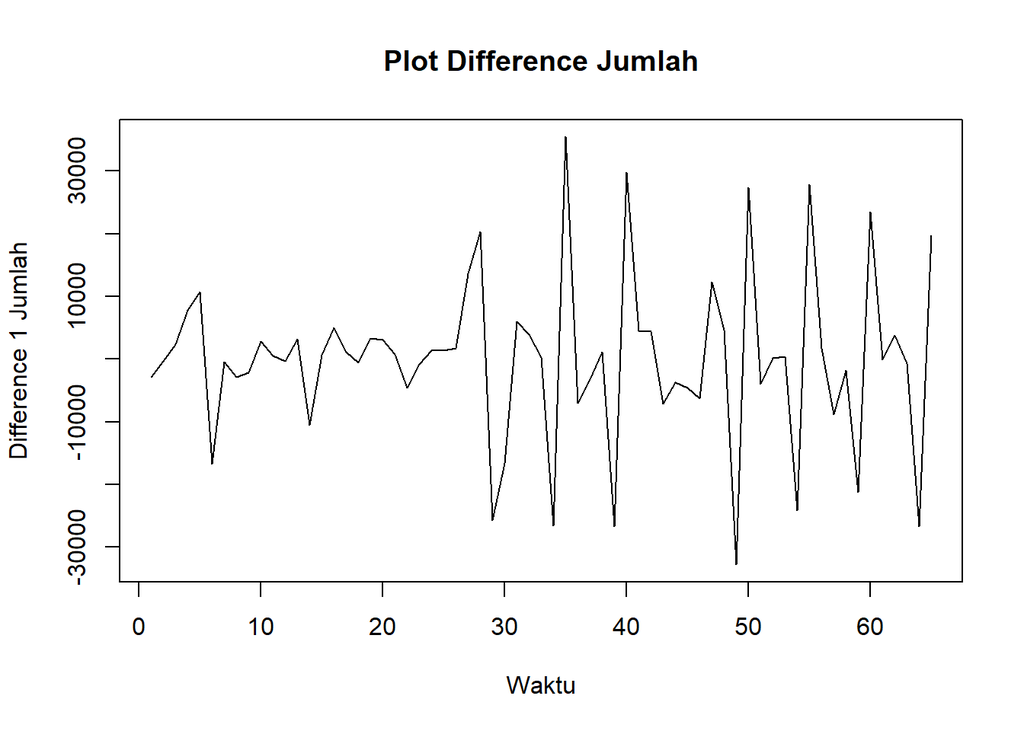

```r
latdif <- diff(latts,differences = 1)
plot.ts(latdif, lty=1, xlab="Waktu", ylab="Difference 1 Jumlah", main="Plot Difference Jumlah")
```

Plot di atas memperlihatkan bentuk data latih yang sudah melalui proses *differencing*. Data terlihat sudah stasioner rataan karena data bergerak pada nilai tengah tertentu.

## Plot ACF

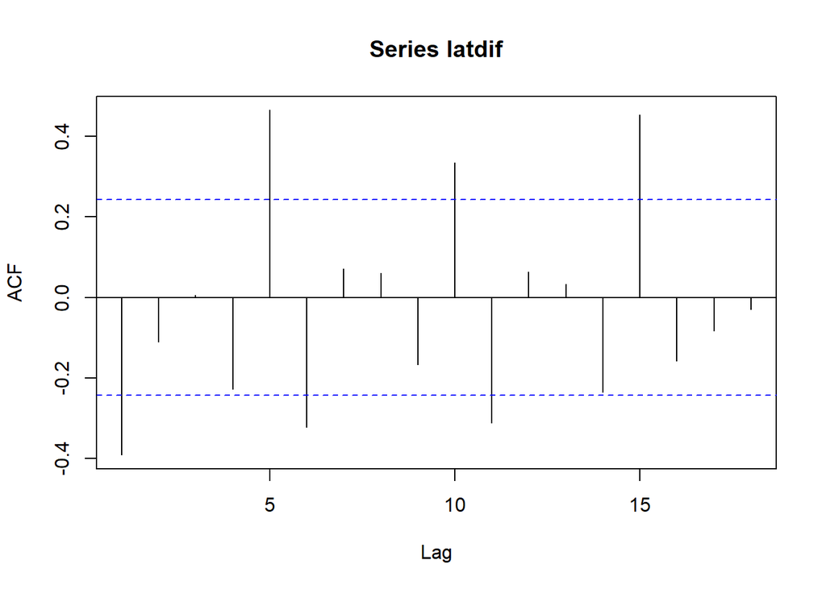

```r
acf(latdif)
```

Berdasarkan plot di atas, data latih yang sudah di*differencing* tidak *tails of slowly*. Artinya data mungkin sudah stasioner dalam rataan. Selanjutnya akan dilakukan uji ADF untuk data latih yang sudah di*differencing*.

## Uji ADF

```r
tseries::adf.test(latdif)
```

```
##
##  Augmented Dickey-Fuller Test
##
## data:  latdif
## Dickey-Fuller = -8.8975, Lag order = 3, p-value = 0.01
## alternative hypothesis: stationary
```

$H_0$ : Data tidak stasioner dalam rataan

$H_1$ : Data stasioner dalam rataan

Nilai p pada uji ADF untuk data latih yang sudah di*differencing* adalah 0,01. Artinya tolak H0, data stasioner dalam rataan. Karena ketidakstasioneran data sudah tertangani, selanjutnya akan dilakukan proses identifikasi model.

# Identifikasi Model

## Plot ACF

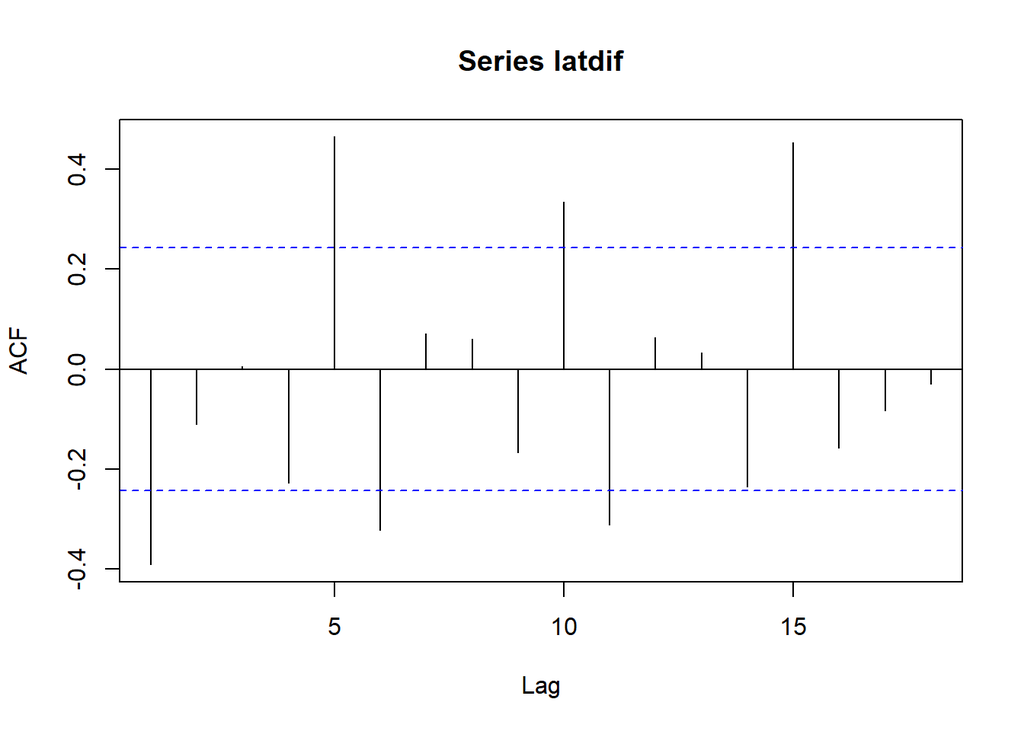

```r
acf(latdif)
```

Plot ACF data latih yang sudah di*differencing* menunjukkan bahwa data *tails of*. Jika dipandang plot ACF *cuts of* pada lag pertama, maka model yang dapat dibentuk adalah **ARIMA(0,1,1)**

## Plot PACF

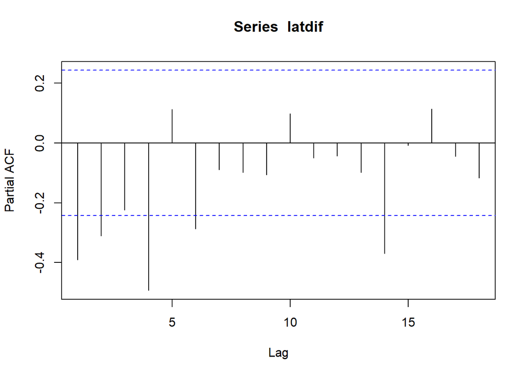

```r
pacf(latdif)
```

Plot PACF data latih yang sudah di*differencing* menunjukkan *tails of*

Karena plot ACF dan PACF data latih yang sudah di*differencing* menunjukkan *tails of*, maka kemungkinan model yang dapat terbentuk adalah **ARIMA(1,1,1)**.

Jika kita melihat plot PACF *cuts of* pada lag ke 2, maka model yang dapat terbentuk adalah **ARIMA(2,1,0)**

## Plot EACF

```r
eacf(latdif)
```

```
## AR/MA
##   0 1 2 3 4 5 6 7 8 9 10 11 12 13
## 0 x o o o x x o o o x x  o  o  o
## 1 x o o o x o o o o o x  o  o  o
## 2 x o o o o o o o o o o  o  o  o
## 3 x x o x o o o o o o o  o  o  o
## 4 o x x o o o o o o o o  o  o  o
## 5 x x o o o o o o o o o  o  o  o
## 6 o o o o x o o o o o o  o  o  o
## 7 x o o o x o o o o o o  o  o  o
```

Plot EACF menunjukkan pola segitiga nol pada model **ARIMA(1,1,2)**,**ARIMA(3,1,4)** dan **ARIMA(4,1,5)**.

# Pendugaan parameter tentatif

Dugaan model yang dapat terbentuk adalah **ARIMA(0,1,1)**, **ARIMA(1,1,1)**,**ARIMA(1,1,2)**, **ARIMA(2,1,0)**, **ARIMA(3,1,4)**, dan **ARIMA(4,1,5)**.

## ARIMA(0,1,1)

```r
model1.da=Arima(latts, order=c(0,1,1),method="ML")
summary(model1.da)
```

```
## Series: latts
## ARIMA(0,1,1)
##
## Coefficients:
##           ma1
##       -0.9408
## s.e.   0.1298
##
## sigma^2 = 1.08e+08:  log likelihood = -693.99
## AIC=1391.98   AICc=1392.18   BIC=1396.33
##
## Training set error measures:
##                     ME     RMSE      MAE       MPE     MAPE      MASE      ACF1
## Training set -206.3209 10235.18 6622.757 -47.27854 63.74388 0.7465018 0.1089379
```

```r
lmtest::coeftest(model1.da)
```

```
##
## z test of coefficients:
##
##     Estimate Std. Error z value  Pr(>|z|)
## ma1 -0.94084    0.12984 -7.2459 4.296e-13 ***
## ---
## Signif. codes:  0 '***' 0.001 '**' 0.01 '*' 0.05 '.' 0.1 ' ' 1
```

## ARIMA(1,1,1)

```r
model2.da=Arima(latts, order=c(1,1,1),method="ML")
summary(model2.da)
```

```
## Series: latts
## ARIMA(1,1,1)
##
## Coefficients:
##          ar1      ma1
##       0.1466  -1.0000
## s.e.  0.1234   0.0705
##
## sigma^2 = 104585641:  log likelihood = -693.29
## AIC=1392.59   AICc=1392.98   BIC=1399.11
##
## Training set error measures:
##                    ME     RMSE      MAE       MPE     MAPE      MASE
## Training set 93.62179 9991.584 6536.017 -45.18715 62.49733 0.7367247
##                       ACF1
## Training set -0.0003408952
```

```r
lmtest::coeftest(model2.da)
```

```
##
## z test of coefficients:
##
##      Estimate Std. Error  z value Pr(>|z|)
## ar1  0.146570   0.123424   1.1875    0.235
## ma1 -0.999998   0.070531 -14.1781   <2e-16 ***
## ---
## Signif. codes:  0 '***' 0.001 '**' 0.01 '*' 0.05 '.' 0.1 ' ' 1
```

## ARIMA(1,1,2)

```r
model3.da=Arima(latts, order=c(1,1,2),method="ML")
summary(model3.da)
```

```
## Series: latts
## ARIMA(1,1,2)
##
## Coefficients:
##           ar1     ma1      ma2
##       -0.7767  0.0000  -1.0000
## s.e.   0.0829  0.1336   0.1336
##
## sigma^2 = 95664821:  log likelihood = -691.02
## AIC=1390.04   AICc=1390.7   BIC=1398.73
##
## Training set error measures:
##                    ME     RMSE      MAE       MPE     MAPE      MASE       ACF1
## Training set 125.5669 9479.818 6750.345 -39.48053 57.81384 0.7608832 0.02351354
```

```r
lmtest::coeftest(model3.da)
```

```
##
## z test of coefficients:
##
##        Estimate  Std. Error z value  Pr(>|z|)
## ar1 -7.7666e-01  8.2878e-02 -9.3711 < 2.2e-16 ***
## ma1  2.1094e-05  1.3359e-01  0.0002    0.9999
## ma2 -9.9996e-01  1.3358e-01 -7.4857 7.117e-14 ***
## ---
## Signif. codes:  0 '***' 0.001 '**' 0.01 '*' 0.05 '.' 0.1 ' ' 1
```

## ARIMA(2,1,0)

```r
model4.da=Arima(latts, order=c(2,1,0),method="ML")
summary(model4.da)
```

```
## Series: latts
## ARIMA(2,1,0)
##
## Coefficients:
##           ar1      ar2
##       -0.5108  -0.3101
## s.e.   0.1179   0.1202
##
## sigma^2 = 140681475:  log likelihood = -701.16
## AIC=1408.33   AICc=1408.72   BIC=1414.85
##
## Training set error measures:
##                     ME     RMSE      MAE       MPE     MAPE      MASE
## Training set -194.9894 11588.22 8456.079 -49.03923 72.53288 0.9531496
##                     ACF1
## Training set -0.07368716
```

```r
lmtest::coeftest(model4.da)
```

```
##
## z test of coefficients:
##
##     Estimate Std. Error z value  Pr(>|z|)
## ar1 -0.51083    0.11788 -4.3335 1.468e-05 ***
## ar2 -0.31011    0.12015 -2.5810   0.00985 **
## ---
## Signif. codes:  0 '***' 0.001 '**' 0.01 '*' 0.05 '.' 0.1 ' ' 1
```

## ARIMA(3,1,4)

```r
model5.da=Arima(latts, order=c(3,1,4),method="ML")
summary(model5.da)
```

```
## Series: latts
## ARIMA(3,1,4)
##
## Coefficients:
##           ar1      ar2      ar3      ma1     ma2     ma3      ma4
##       -0.3332  -0.5817  -0.7988  -0.4154  0.0001  0.4154  -0.9999
## s.e.   0.0955   0.0558   0.0833   0.1385  0.1314  0.1331   0.1369
##
## sigma^2 = 89330732:  log likelihood = -688.2
## AIC=1392.41   AICc=1394.98   BIC=1409.8
##
## Training set error measures:
##                    ME     RMSE      MAE       MPE     MAPE      MASE
## Training set 151.1091 8860.179 6274.876 -33.73593 50.95745 0.7072894
##                     ACF1
## Training set -0.04026831
```

```r
lmtest::coeftest(model5.da)
```

```
##
## z test of coefficients:
##
##        Estimate  Std. Error  z value  Pr(>|z|)
## ar1 -3.3323e-01  9.5509e-02  -3.4890 0.0004848 ***
## ar2 -5.8170e-01  5.5764e-02 -10.4315 < 2.2e-16 ***
## ar3 -7.9877e-01  8.3294e-02  -9.5898 < 2.2e-16 ***
## ma1 -4.1542e-01  1.3853e-01  -2.9989 0.0027099 **
## ma2  7.0227e-05  1.3136e-01   0.0005 0.9995735
## ma3  4.1536e-01  1.3306e-01   3.1215 0.0017990 **
## ma4 -9.9992e-01  1.3690e-01  -7.3039 2.794e-13 ***
## ---
## Signif. codes:  0 '***' 0.001 '**' 0.01 '*' 0.05 '.' 0.1 ' ' 1
```

## ARIMA(4,1,5)

```r
model6.da=Arima(latts, order=c(4,1,5),method="ML")
summary(model6.da)
```

```
## Series: latts
## ARIMA(4,1,5)
##
## Coefficients:
##           ar1      ar2      ar3      ar4     ma1      ma2      ma3      ma4
##       -1.3176  -0.8047  -0.1383  -0.2438  0.7670  -0.3594  -0.9604  -0.1712
## s.e.   0.4672   0.7775   0.6306   0.3013  0.4692   0.5297   0.3268   0.5638
##          ma5
##       0.0992
## s.e.  0.3709
##
## sigma^2 = 86106558:  log likelihood = -683.52
## AIC=1387.04   AICc=1391.11   BIC=1408.78
##
## Training set error measures:
##                     ME     RMSE     MAE       MPE     MAPE     MASE        ACF1
## Training set -286.7849 8547.521 6035.38 -32.07825 47.61034 0.680294 -0.01479913
```

```r
lmtest::coeftest(model6.da)
```

```
##
## z test of coefficients:
##
##      Estimate Std. Error z value Pr(>|z|)
## ar1 -1.317646   0.467217 -2.8202 0.004799 **
## ar2 -0.804681   0.777486 -1.0350 0.300679
## ar3 -0.138283   0.630576 -0.2193 0.826419
## ar4 -0.243815   0.301303 -0.8092 0.418398
## ma1  0.766981   0.469195  1.6347 0.102118
## ma2 -0.359393   0.529716 -0.6785 0.497478
## ma3 -0.960409   0.326761 -2.9392 0.003291 **
## ma4 -0.171212   0.563813 -0.3037 0.761382
## ma5  0.099165   0.370936  0.2673 0.789209
## ---
## Signif. codes:  0 '***' 0.001 '**' 0.01 '*' 0.05 '.' 0.1 ' ' 1
```

## Nilai AIC

```r
cat("AIC Model ARIMA (0,1,1) :", model1.da$aic,
    "\nAIC Model ARIMA (1,1,1) :", model2.da$aic,
    "\nAIC Model ARIMA (1,1,2) :", model3.da$aic,
    "\nAIC Model ARIMA (2,1,0) :", model4.da$aic,
    "\nAIC Model ARIMA (3,1,4) :", model5.da$aic,
    "\nAIC Model ARIMA (4,1,5) :", model6.da$aic)
```

```
## AIC Model ARIMA (0,1,1) : 1391.985
## AIC Model ARIMA (1,1,1) : 1392.589
## AIC Model ARIMA (1,1,2) : 1390.036
## AIC Model ARIMA (2,1,0) : 1408.328
## AIC Model ARIMA (3,1,4) : 1392.407
## AIC Model ARIMA (4,1,5) : 1387.04
```

Model yang akan dipilih adalah model **ARIMA(2,1,0)**. Walau memiliki nilai AIC paling besar, namun semua parameter pada model ARIMA(2,1,0) signifikan pada taraf nyata 95%.

```r
lmtest::coeftest(model4.da)
```

```
##
## z test of coefficients:
##
##     Estimate Std. Error z value  Pr(>|z|)
## ar1 -0.51083    0.11788 -4.3335 1.468e-05 ***
## ar2 -0.31011    0.12015 -2.5810   0.00985 **
## ---
## Signif. codes:  0 '***' 0.001 '**' 0.01 '*' 0.05 '.' 0.1 ' ' 1
```

# Overfitting

Selanjutnya pemeriksaan model *overfitting* dari ARIMA(2,1,0), yakni ARIMA(3,1,0) dan ARIMA(2,1,1).

## ARIMA(3,1,0)

```r
model7.da=Arima(latts, order=c(3,1,0),method="ML")
summary(model7.da)
```

```
## Series: latts
## ARIMA(3,1,0)
##
## Coefficients:
##           ar1      ar2      ar3
##       -0.5765  -0.4204  -0.2195
## s.e.   0.1207   0.1323   0.1228
##
## sigma^2 = 1.36e+08:  log likelihood = -699.61
## AIC=1407.22   AICc=1407.89   BIC=1415.92
##
## Training set error measures:
##                     ME    RMSE      MAE       MPE    MAPE      MASE      ACF1
## Training set -187.0145 11302.1 8106.096 -49.38667 71.6152 0.9137003 -0.114979
```

```r
lmtest::coeftest(model7.da)
```

```
##
## z test of coefficients:
##
##     Estimate Std. Error z value  Pr(>|z|)
## ar1 -0.57646    0.12073 -4.7749 1.798e-06 ***
## ar2 -0.42038    0.13234 -3.1765   0.00149 **
## ar3 -0.21954    0.12278 -1.7880   0.07377 .
## ---
## Signif. codes:  0 '***' 0.001 '**' 0.01 '*' 0.05 '.' 0.1 ' ' 1
```

## ARIMA(2,1,1)

```r
model8.da=Arima(latts, order=c(2,1,1),method="ML")
summary(model8.da)
```

```
## Series: latts
## ARIMA(2,1,1)
##
## Coefficients:
##          ar1      ar2      ma1
##       0.1547  -0.0815  -0.9999
## s.e.  0.1235   0.1284   0.0855
##
## sigma^2 = 105352501:  log likelihood = -693.09
## AIC=1394.19   AICc=1394.86   BIC=1402.89
##
## Training set error measures:
##                    ME     RMSE      MAE       MPE   MAPE      MASE        ACF1
## Training set 121.0645 9948.241 6512.273 -44.81148 62.152 0.7340483 -0.01393717
```

```r
lmtest::coeftest(model8.da)
```

```
##
## z test of coefficients:
##
##      Estimate Std. Error  z value Pr(>|z|)
## ar1  0.154728   0.123531   1.2525   0.2104
## ar2 -0.081495   0.128389  -0.6347   0.5256
## ma1 -0.999902   0.085453 -11.7012   <2e-16 ***
## ---
## Signif. codes:  0 '***' 0.001 '**' 0.01 '*' 0.05 '.' 0.1 ' ' 1
```